# Kaggle Axa Project

Alejandra Jaimes, Alex Signal, Christopher Peter Makris, Dani Ismail

July 2015

```r
library(ggplot2)
library(GGally)
library(corrplot)
library(stats)
library(VIM)
library(AUCRF)
library(rpart)
```

### 0.0.2 Loading Data

```r
load("Data/small_axa.RData")
```

### 0.0.3 Data preparation

Preparing data frame by converting variables to numeric.

```r
dim(axa) #600 Observations, 88 Variables
names(axa)
sapply(axa, class)
table(sapply(axa, class)) #Characters need to be converted to numeric type.
```

```r
###Converting character variables to numeric variables.
converted.columns = sapply(axa[, 2:87], as.numeric)
axa.converted = data.frame(axa[, 1], converted.columns, axa[, 88])
names(axa.converted) = names(axa)

axa.converted$driver = as.factor(substr(axa.converted$driver_trip, 1, 1))
names <- names(axa.converted)
names <- gsub("-", "_", names)
names(axa.converted) <- names
remove(axa)
axa = axa.converted
remove(axa.converted)
```

### 0.0.4 Data Exploration

```r
summary(axa)
```

```
##   driver_trip    accel_mean        accel_quantile.0.  accel_quantile.100.
##  1_1    :  1   Min.   :-0.198718   Min.   :-84.7783   Min.   : 0.6325
##  1_10   :  1   1st Qu.:-0.017826   1st Qu.: -4.6123   1st Qu.: 2.4250
##  1_100  :  1   Median :-0.008267   Median : -3.4003   Median : 3.3388
##  1_101  :  1   Mean   :-0.012099   Mean   : -5.5076   Mean   : 5.5215
##  1_102  :  1   3rd Qu.:-0.001115   3rd Qu.: -2.4777   3rd Qu.: 4.5519
##  1_103  :  1   Max.   : 0.034406   Max.   : -0.6325   Max.   :84.7783
##  (Other):594
##  accel_quantile.25. accel_quantile.50.   accel_quantile.75.
##  Min.   :-0.8961    Min.   :-0.0557835   Min.   :0.0000
##  1st Qu.:-0.4138    1st Qu.: 0.0000000   1st Qu.:0.2236
##  Median :-0.3159    Median : 0.0000000   Median :0.3101
##  Mean   :-0.3375    Mean   :-0.0004771   Mean   :0.3250
##  3rd Qu.:-0.2472    3rd Qu.: 0.0000000   3rd Qu.:0.4182
##  Max.   : 0.0000    Max.   : 0.0793240   Max.   :0.9431
##
##     accel_sd       angle_change       angle_mean      angle_quantile.0.
##  Min.   :0.1499   Min.   :-115943   Min.   :-94.328   Min.   :-179.80
##  1st Qu.:0.6214   1st Qu.:  -6846   1st Qu.:-14.280   1st Qu.:-179.01
##  Median :0.7915   Median :   3349   Median :  7.063   Median :-176.63
##  Mean   :0.8587   Mean   :   5040   Mean   :  7.429   Mean   :-170.61
##  3rd Qu.:0.9396   3rd Qu.:  14812   3rd Qu.: 28.372   3rd Qu.:-168.69
##  Max.   :8.3605   Max.   : 104385   Max.   :117.447   Max.   : -78.69
##
##  angle_quantile.100. angle_quantile.25. angle_quantile.50.
##  Min.   : 90.0       Min.   :-169.87    Min.   :-141.669
##  1st Qu.:180.0       1st Qu.: -81.49    1st Qu.:  -4.169
##  Median :180.0       Median : -36.26    Median :   0.000
##  Mean   :178.6       Mean   : -42.85    Mean   :   7.217
##  3rd Qu.:180.0       3rd Qu.:   0.00    3rd Qu.:  29.801
##  Max.   :180.0       Max.   : 104.04    Max.   : 139.236
##
##  angle_quantile.75.    angle_sd       angletodest       direct_dist
##  Min.   :-80.15     Min.   : 28.79   Min.   :-3.1333   Min.   :    0.943
##  1st Qu.: 14.08     1st Qu.: 64.60   1st Qu.:-1.1153   1st Qu.:  874.363
##  Median : 54.58     Median : 77.76   Median : 0.1700   Median : 2183.850
##  Mean   : 58.17     Mean   : 79.99   Mean   : 0.1226   Mean   : 3535.720
##  3rd Qu.: 94.49     3rd Qu.: 94.61   3rd Qu.: 1.4287   3rd Qu.: 4241.216
##  Max.   :167.11     Max.   :144.02   Max.   : 3.0960   Max.   :16594.256
##
```

[output cut: 153 more lines]

```
##  Min.   : 0.4614   Min.   :  0.6325   Min.   :   0.0894   Mode :logical
##  1st Qu.: 3.8790   1st Qu.:  2.7323   1st Qu.:   3.6714   FALSE:165
##  Median : 4.5556   Median :  3.7311   Median :   4.7643   TRUE :435
##  Mean   : 4.6972   Mean   :  6.8843   Mean   :  15.0737   NA's :0
##  3rd Qu.: 5.2723   3rd Qu.:  5.5073   3rd Qu.:   5.8027
##  Max.   :12.0187   Max.   :359.0252   Max.   :1774.4807
##  NA's   :1
##  driver
##  1:200
##  2:200
##  3:200
##
##
##
##
```

Checking for NA values.

```r
sum(is.na(axa)) #3,375 missing values.
na.list = as.data.frame(sapply(axa, function(x) { sum(is.na(x)) })) #Focused in certain variables.
na.list$variable = rownames(na.list)
colnames(na.list) = c("sum.na","variable")
rownames(na.list) <- NULL
na.list[order(na.list$sum.na, decreasing = TRUE), ]
```

Creating boxplots split by driver type and response.

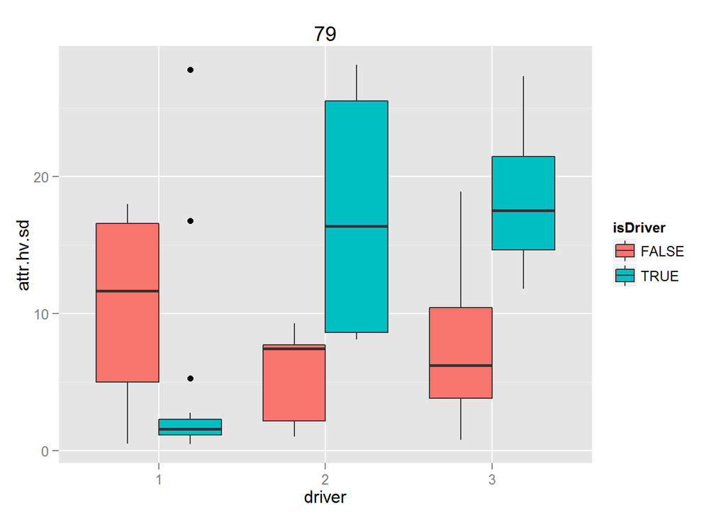

```r
var_list = names(axa)[1:89]
boxplot_list = list("null")

for (i in 2:88) {
    p = ggplot(data=axa,aes_string(x=var_list[[89]], y=var_list[[i]],
                                   fill= var_list[[88]])) +
          geom_boxplot() + ggtitle(i)
    boxplot_list[[i]] = p
    }
boxplot_list [[79]]
```

Creating scatter plot matrix

```r
#change eval = TRUE to create this plot. It requires a lot of computation.
axa2 = axa
axa2$isDriver = as.factor(axa2$isDriver)
ggpairs(data=axa2[,c(3, 4, 5, 7, 8, 18, 23, 24, 28, 32, 34, 48, 74, 75, 76, 77, 78, 79, 84, 85,88)], color ="isDriver" )
```

From the boxplots, variable attr.hv.sd shows high variances when comparing different drivers and the reponse.

However this variable has 552/600 empty values. Since we consider this can be a variable that could predict the reponse. We decided to impute ths variable and check if we can use it in our model.

Checking the correlation with variable 79 (attr.hv.sd) and selecting the max and min correlations.

```r
correlation_axa = cor(axa[,79] , axa[,2:87] , use = "pairwise.complete.obs")
cor_axa_t = t(correlation_axa)
which.min(cor_axa_t)
```

```
## [1] 2
```

```r
which.max(cor_axa_t[-78,])
```

```
## accel_quantile.100.
##                   3
```

The variables with the highest correlations are: accel_quantile.0. and accel_quantile.100..

We picked variable accel_quantile.0. with the highest correlation with variable 79.

### 0.0.5 Data transformation - Imputing variable

Using linear regression to impute the values.

First model using variable accel.quantile.0 variable to predict attr.hv.sd

```r
model = lm(attr.hv.sd ~ accel_quantile.0., data = axa)
summary(model)
```

```
##
## Call:
## lm(formula = attr.hv.sd ~ accel_quantile.0., data = axa)
##
## Residuals:
##      Min       1Q   Median       3Q      Max
## -23.0825  -1.3459  -0.3257   2.2155   8.2044
##
## Coefficients:
##                   Estimate Std. Error t value Pr(>|t|)
## (Intercept)        0.74535    1.04885   0.711    0.481
## accel_quantile.0. -0.35111    0.03698  -9.494 2.07e-12 ***
## ---
## Signif. codes:  0 '***' 0.001 '**' 0.01 '*' 0.05 '.' 0.1 ' ' 1
##
## Residual standard error: 5.035 on 46 degrees of freedom
##   (552 observations deleted due to missingness)
## Multiple R-squared:  0.6621, Adjusted R-squared:  0.6547
## F-statistic: 90.13 on 1 and 46 DF,  p-value: 2.068e-12
```

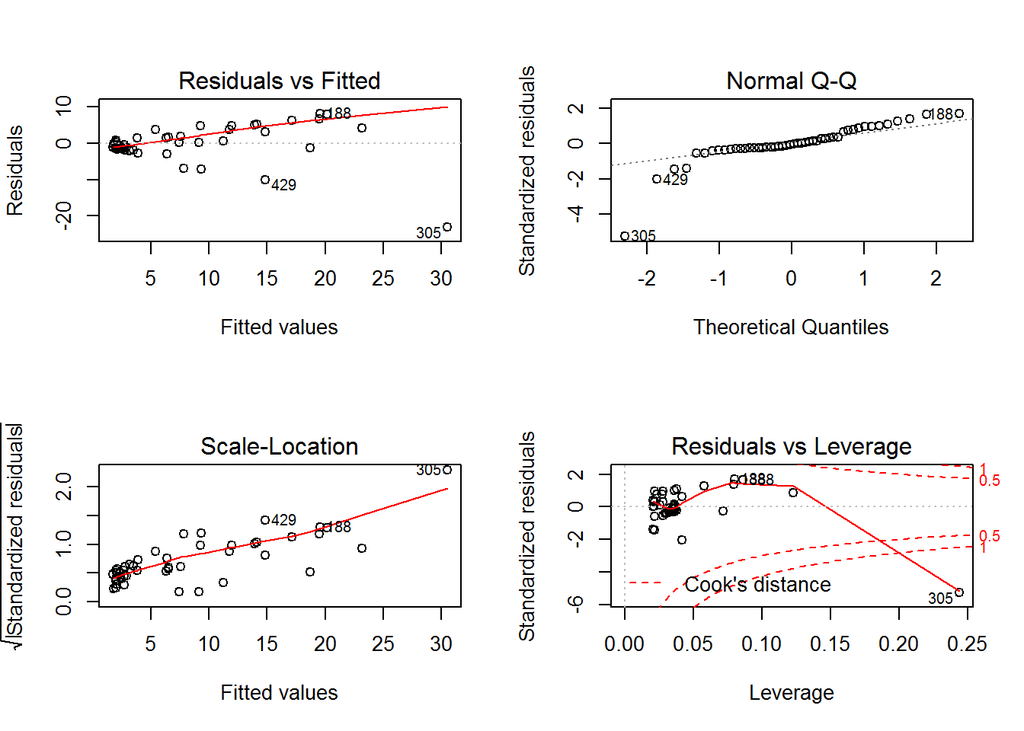

```r
par(mfrow=c(2, 2))
plot(model)
```

From the “fitted vs residuals values”" plot a pattern is observed.

Checking for transformations:

```r
library(MASS)
bc = boxcox(model)
```

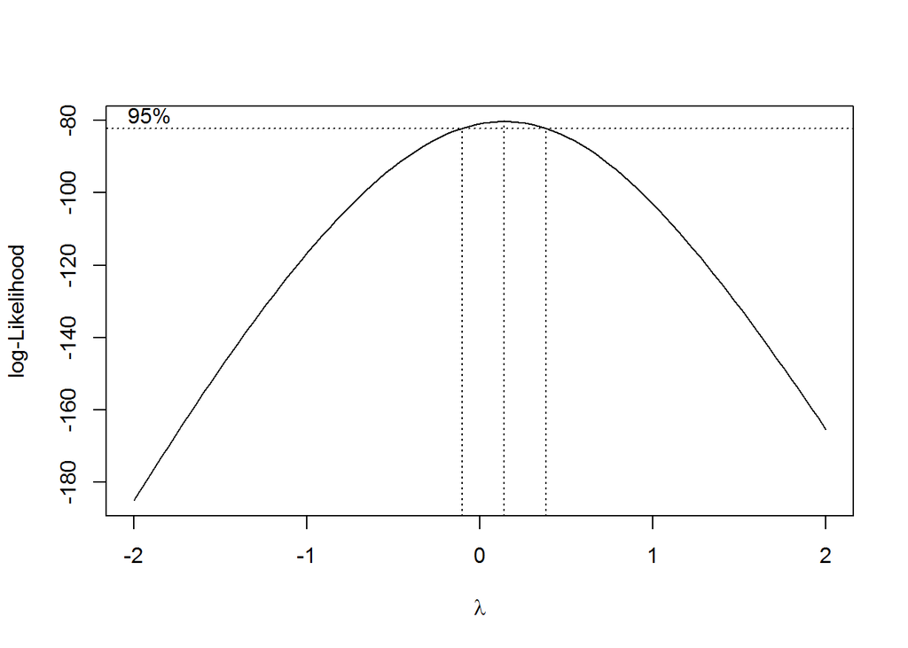

```r
which(bc$y == max(bc$y))
```

```
## [1] 54
```

```r
bc$x[54]
```

```
## [1] 0.1414141
```

The boxcox plot shows that we can apply a transformation to remove the pattern.

Transforming the data by taking the max point of the boxcox transformation, and using it in a new imputing model:

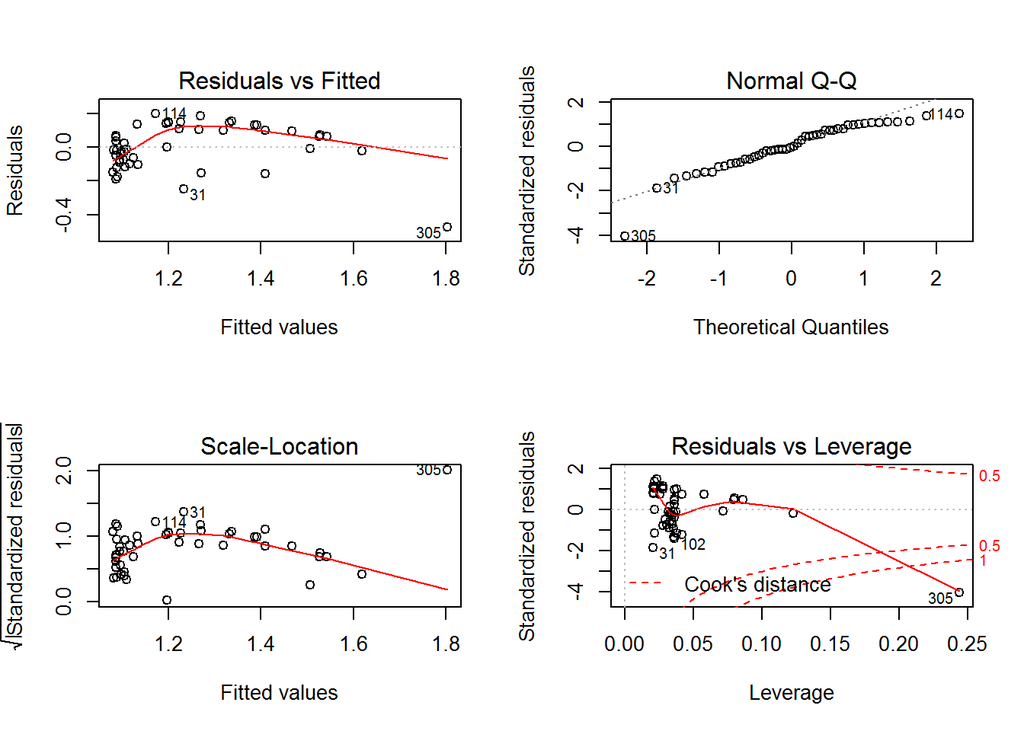

```r
transformed = axa$attr.hv.sd^bc$x[54]
model2 = lm(transformed ~ accel_quantile.0., data = axa)

par(mfrow=c(2, 2))
plot(model2)
```

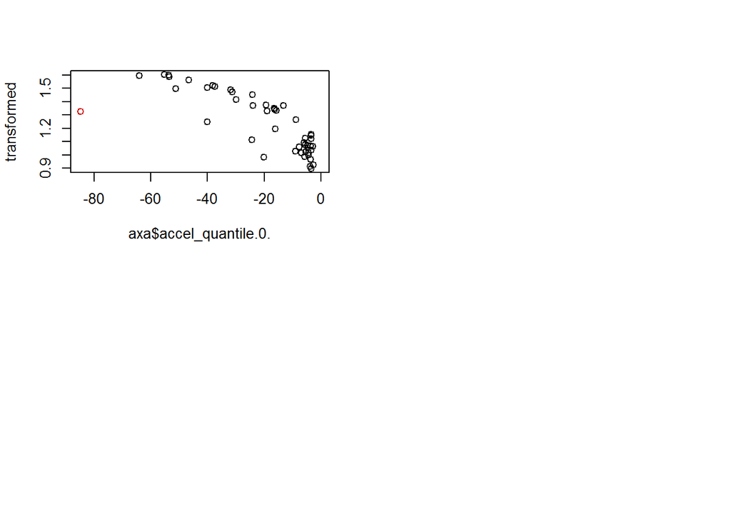

```r
col.vec = rep(1, nrow(axa))
col.vec[305] = "red3"
plot(transformed ~ axa$accel_quantile.0., col = col.vec)
```

From model2, a leverage point (observation 305) is analyzed.

In the following model the levarage point is removed.

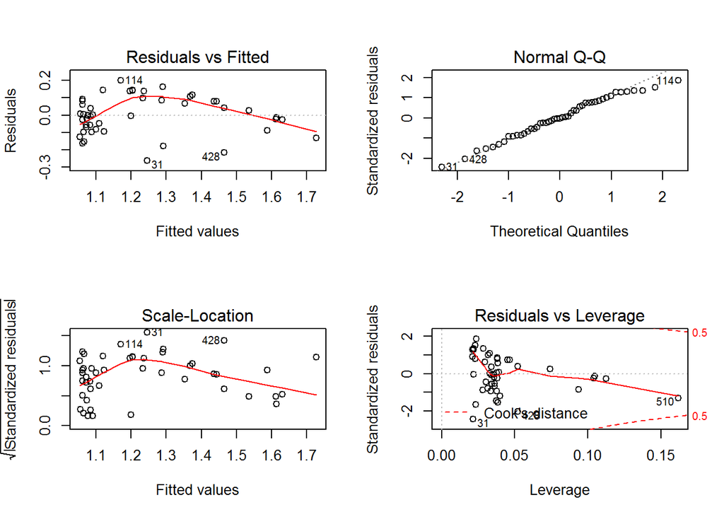

```r
acceleration = axa$accel_quantile.0.[-305]

model3 = lm(transformed[-305] ~ acceleration, data = axa)
par(mfrow=c(2, 2))
plot(model3)
```

```r
summary(model3)
```

```
##
## Call:
## lm(formula = transformed[-305] ~ acceleration, data = axa)
##
## Residuals:
##       Min        1Q    Median        3Q       Max
## -0.262338 -0.077231 -0.002967  0.083831  0.200053
##
## Coefficients:
##               Estimate Std. Error t value Pr(>|t|)
## (Intercept)   1.023476   0.023631   43.31  < 2e-16 ***
## acceleration -0.011000   0.000914  -12.04 1.16e-15 ***
## ---
## Signif. codes:  0 '***' 0.001 '**' 0.01 '*' 0.05 '.' 0.1 ' ' 1
##
## Residual standard error: 0.1093 on 45 degrees of freedom
##   (552 observations deleted due to missingness)
## Multiple R-squared:  0.763,  Adjusted R-squared:  0.7577
## F-statistic: 144.8 on 1 and 45 DF,  p-value: 1.155e-15
```

The R-squared value after removing the levarage improved from 0.6249828 to 0.7576837

Model3 is now used to impute the missing values.

```r
input = axa$accel_quantile.0.[is.na(axa$attr.hv.sd)] #Selecting predictor values
#with attr.hv.sd = NA.

index = which(is.na(axa$attr.hv.sd)) #keeping the index of NA rows
imputed.values = predict(model3,  newdata = data.frame(acceleration=input))

axa$attr.hv.sd.imputed = transformed
axa[index,"attr.hv.sd.imputed"]  = imputed.values
```

After we imputed, it smoothed out all the differences since we had to impute about 90% of the variable. As shown below, “driver” ended up not being significant:

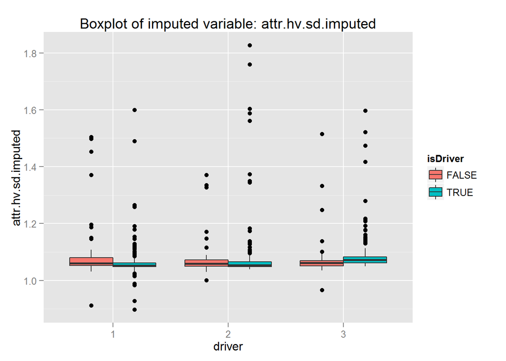

```r
ggplot(data=axa,aes(x=driver, y= attr.hv.sd.imputed,
            fill= isDriver)) +
            geom_boxplot() +
            ggtitle("Boxplot of imputed variable: attr.hv.sd.imputed")
```

```r
aov_prior = aov(axa$attr.hv.sd ~ axa$driver + axa$isDriver)
summary(aov_prior)
```

```
##              Df Sum Sq Mean Sq F value  Pr(>F)
## axa$driver    2  667.7   333.8   5.356 0.00828 **
## axa$isDriver  1   41.2    41.2   0.661 0.42053
## Residuals    44 2742.7    62.3
## ---
## Signif. codes:  0 '***' 0.001 '**' 0.01 '*' 0.05 '.' 0.1 ' ' 1
## 552 observations deleted due to missingness
```

```r
aov_post = aov(axa$attr.hv.sd.imputed ~ axa$driver + axa$isDriver)
summary(aov_post)
```

```
##               Df Sum Sq  Mean Sq F value Pr(>F)
## axa$driver     2  0.021 0.010668   1.256  0.285
## axa$isDriver   1  0.000 0.000225   0.027  0.871
## Residuals    596  5.061 0.008491
```

### 0.0.6 Machine Learning

#### 0.0.6.1 Regression model using imputed variable

Testing a model using the imputed variable:

!!! review - Chris I dont know if this is similar to the model you tried. I couldnt find it in your code

```r
model_lm = glm(as.factor(isDriver) ~ attr.hv.sd.imputed,
               data = axa,
               family = "binomial")
model_lm
```

```
##
## Call:  glm(formula = as.factor(isDriver) ~ attr.hv.sd.imputed, family = "binomial",
##     data = axa)
##
## Coefficients:
##        (Intercept)  attr.hv.sd.imputed
##              1.129              -0.147
##
## Degrees of Freedom: 599 Total (i.e. Null);  598 Residual
## Null Deviance:       705.8
## Residual Deviance: 705.8     AIC: 709.8
```

```r
pred <- ifelse(predict(model_lm,type="response") > 0.5,"TRUE","FALSE")
table(pred,as.factor(axa$isDriver))
```

```
##
## pred   FALSE TRUE
##   TRUE   165  435
```

```r
# pred   FALSE TRUE
#   TRUE   165  435
```

The table above shows that all “False” are missclassified.

#### 0.0.6.2 Random Forests

##### 0.0.6.2.1 Imputing and cleaning data

Because using variable 79, could not help to predict isDriver, then variables with more than 550 NA cells will be removed. Variables with small number of missing values are imputed using knn.

```r
axa.new = axa[, -c(1, 74:79, 90)]
axa.knn = kNN(axa.new)
```

```
## Time difference of 1.338472 secs
```

```r
axa.imputed = axa.knn[, 1:82]
```

Converting isDriver to factor( False = 0, True =1 ) to be used in AUC

```r
axa.imputed$isDriver = as.factor(axa.imputed$isDriver)
levels(axa.imputed$isDriver) = c(0,1)
```

#### 0.0.6.3 Building Random Forest

For this model, the package AUCRF is used. “AUCRF is an algorithm for variable selection using Random Forest based on optimizing the areaunder-the ROC curve (AUC) of the Random Forest.” (https://cran.r-project.org/web/packages/AUCRF/AUCRF.pdf)

For these models Gini is the importance of measure for ranking the variables.

##### 0.0.6.3.1 1.1) RF using “driver” variable

```r
set.seed(12345)
fit = AUCRF(isDriver ~ .,
            ntree = 1000,
            data = axa.imputed) #.8837

saveRDS(fit,"Models/fit.rds")
```

```r
fit = readRDS("Models/fit.rds")
summary(fit)
```

```
##
## Number of selected variables: Kopt= 15
## AUC of selected variables: OOB-AUCopt= 0.8836782
## Importance Measure: MDG
##
##    Selected.Variables Importance
## 1   jerk_quantile.25.   8.493631
## 2   jerk_quantile.75.   8.153262
## 3         direct_dist   5.819660
## 4      attr.turn.v.sd   5.759082
## 5     attr.turn.ap.sd   5.538509
## 6     attr.turn.al.sd   5.411454
## 7   attr.turn.ap.mean   5.173398
## 8             max.ap.   5.002162
## 9            accel_sd   4.422512
## 10 accel_quantile.25.   4.250917
## 11 accel_quantile.75.   4.166144
## 12           speed_sd   4.117809
## 13                len   4.066725
## 14             driver   3.841816
## 15    path_efficiency   3.804031
```

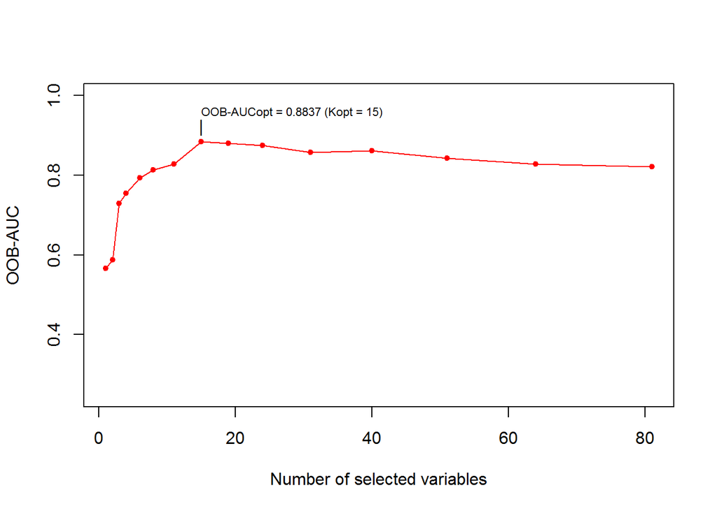

```r
plot(fit)
```

Using cross-validation and random forest:

```r
fit.cv = AUCRFcv(fit,
                 nCV = 10, ###Number of folds.
                 M = 10) ###Number of CV repetitions.
saveRDS(fit.cv,"Models/fit.cv.rds")
```

```r
fit.cv = readRDS("Models/fit.cv.rds")
summary(fit.cv)
```

```
##
## Number of selected variables: Kopt= 15
## AUC of selected variables: OOB-AUCopt= 0.8836782
## AUC from cross validation: 0.8540648
## Importance Measure: MDG
##
##    Selected.Variables Importance Prob.Select
## 1   jerk_quantile.25.   8.493631        1.00
## 2   jerk_quantile.75.   8.153262        1.00
## 3         direct_dist   5.819660        1.00
## 4      attr.turn.v.sd   5.759082        1.00
## 5     attr.turn.ap.sd   5.538509        1.00
## 6     attr.turn.al.sd   5.411454        1.00
## 7   attr.turn.ap.mean   5.173398        1.00
## 8             max.ap.   5.002162        1.00
## 9            accel_sd   4.422512        1.00
## 10 accel_quantile.25.   4.250917        0.96
## 11 accel_quantile.75.   4.166144        0.94
## 12           speed_sd   4.117809        0.97
## 13                len   4.066725        0.99
## 14             driver   3.841816        0.99
## 15    path_efficiency   3.804031        0.98
```

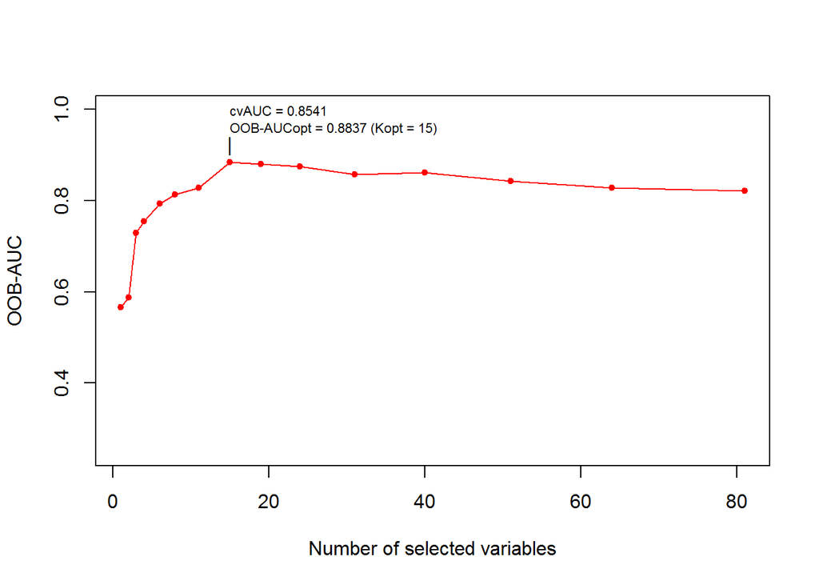

```r
plot(fit.cv)
```

```r
names(fit.cv)
```

```
##  [1] "call"       "data"       "ranking"    "Xopt"       "OOB-AUCopt"
##  [6] "Kopt"       "AUCcurve"   "RFopt"      "ImpMeasure" "cvAUC"
## [11] "Psel"       "callcv"
```

```r
# Number of selected variables: Kopt= 15
# AUC of selected variables: OOB-AUCopt= 0.8902264
# AUC from cross validation: 0.8520655
# Importance Measure: MDG
```

The mean AUC from cross-validation is: 0.8540648 with 15 selected optimal variables

The optimal variables to use are: jerk_quantile.25., jerk_quantile.75., direct_dist, attr.turn.v.sd, attr.turn.ap.sd, attr.turn.al.sd, attr.turn.ap.mean, max.ap., accel_sd, accel_quantile.25., accel_quantile.75., speed_sd, len, driver, path_efficiency

##### 0.0.6.3.2 1.2) RF using “driver” variable and changing node size

```r
set.seed(12345)
fit_nodesize = AUCRF(isDriver ~ .,
            ntree = 1000,
            nodesize = 6,
            data = axa.imputed) #.8809

saveRDS(fit_nodesize,"Models/fit_nodesize.rds")
```

```r
fit_nodesize = readRDS("Models/fit_nodesize.rds")
summary(fit_nodesize) # auc = 0.88
```

```
##
## Number of selected variables: Kopt= 11
## AUC of selected variables: OOB-AUCopt= 0.8809265
## Importance Measure: MDG
##
##    Selected.Variables Importance
## 1   jerk_quantile.25.   8.378007
## 2   jerk_quantile.75.   7.019110
## 3         direct_dist   5.928880
## 4      attr.turn.v.sd   5.478846
## 5     attr.turn.ap.sd   5.164583
## 6     attr.turn.al.sd   4.971816
## 7   attr.turn.ap.mean   4.825591
## 8             max.ap.   4.739639
## 9            accel_sd   4.089850
## 10 accel_quantile.25.   3.855701
## 11             driver   3.801033
```

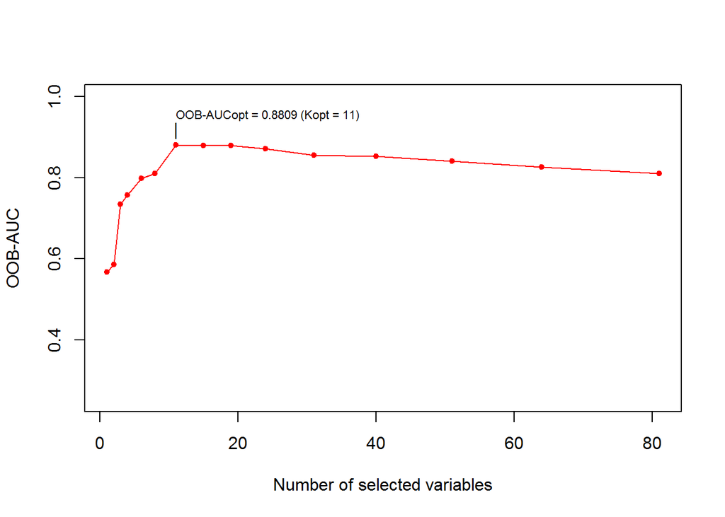

```r
plot(fit_nodesize) # 11
```

Cross-validation using the fit_nodesize model:

```r
fit.cv.nodesize = AUCRFcv(fit_nodesize,
                 nCV = 10, ###Number of folds.
                 M = 10) ###Number of CV repetitions.
saveRDS(fit.cv.nodesize,"Models/fit.cv.nodesize.rds")
```

```r
fit.cv.nodesize = readRDS("Models/fit.cv.nodesize.rds")
summary(fit.cv.nodesize) # auc =0.857, 11 kopt
```

```
##
## Number of selected variables: Kopt= 11
## AUC of selected variables: OOB-AUCopt= 0.8809265
## AUC from cross validation: 0.8569864
## Importance Measure: MDG
##
##    Selected.Variables Importance Prob.Select
## 1   jerk_quantile.25.   8.378007        1.00
## 2   jerk_quantile.75.   7.019110        1.00
## 3         direct_dist   5.928880        1.00
## 4      attr.turn.v.sd   5.478846        1.00
## 5     attr.turn.ap.sd   5.164583        1.00
## 6     attr.turn.al.sd   4.971816        1.00
## 7   attr.turn.ap.mean   4.825591        0.99
## 8             max.ap.   4.739639        1.00
## 9            accel_sd   4.089850        0.98
## 10 accel_quantile.25.   3.855701        0.97
## 11             driver   3.801033        1.00
```

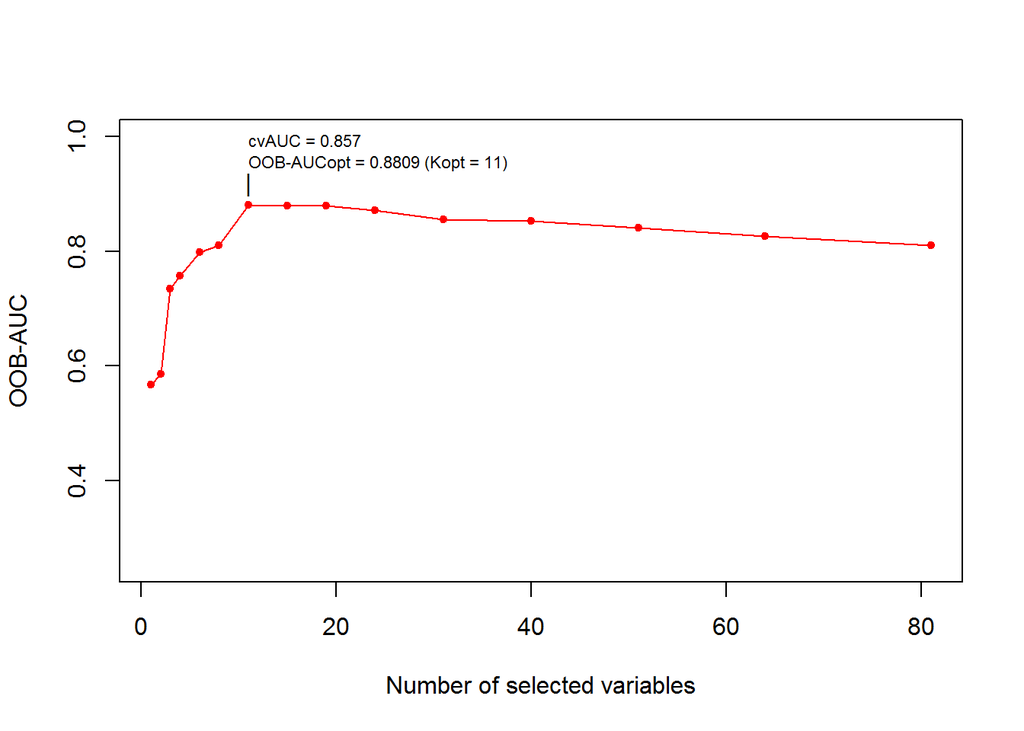

```r
plot(fit.cv.nodesize)
```

```r
names(fit.cv.nodesize)
```

```
##  [1] "call"       "data"       "ranking"    "Xopt"       "OOB-AUCopt"
##  [6] "Kopt"       "AUCcurve"   "RFopt"      "ImpMeasure" "cvAUC"
## [11] "Psel"       "callcv"
```

The mean AUC from cross-validation is: 0.8569864 with 11 selected optimal variables.

###### 0.0.6.3.2.1 Building Classification Tree

```r
final.model = rpart(isDriver ~ jerk_quantile.25. +
                      jerk_quantile.75. +
                      direct_dist +
                      attr.turn.ap.sd +
                      attr.turn.v.sd +
                      attr.turn.al.sd +
                      max.ap. +
                      attr.turn.ap.mean +
                      accel_sd +
                      accel_quantile.25. +
                      speed_sd +
                      accel_quantile.75. +
                      driver +
                      jerk_sd +
                      path_efficiency,
                    data = axa.imputed,
                    control = rpart.control(minbucket = 1))

final.model
```

```
## n= 600
##
## node), split, n, loss, yval, (yprob)
##       * denotes terminal node
##
##    1) root 600 165 1 (0.27500000 0.72500000)
##      2) jerk_quantile.25.< -0.7201894 50  16 0 (0.68000000 0.32000000)
##        4) attr.turn.v.sd>=4.297368 29   4 0 (0.86206897 0.13793103) *
##        5) attr.turn.v.sd< 4.297368 21   9 1 (0.42857143 0.57142857)
##         10) driver=2,3 7   1 0 (0.85714286 0.14285714) *
##         11) driver=1 14   3 1 (0.21428571 0.78571429)
##           22) direct_dist>=1259.211 2   0 0 (1.00000000 0.00000000) *
##           23) direct_dist< 1259.211 12   1 1 (0.08333333 0.91666667) *
##      3) jerk_quantile.25.>=-0.7201894 550 131 1 (0.23818182 0.76181818)
##        6) direct_dist< 2759.136 282  95 1 (0.33687943 0.66312057)
##         12) path_efficiency>=0.5772498 94  46 1 (0.48936170 0.51063830)
##           24) attr.turn.al.sd>=0.7268276 75  32 0 (0.57333333 0.42666667)
##             48) attr.turn.ap.mean< 0.5235531 17   1 0 (0.94117647 0.05882353) *
##             49) attr.turn.ap.mean>=0.5235531 58  27 1 (0.46551724 0.53448276)
##               98) direct_dist>=1228.108 34  14 0 (0.58823529 0.41176471)
##                196) attr.turn.ap.sd< 0.6493804 11   1 0 (0.90909091 0.09090909) *
##                197) attr.turn.ap.sd>=0.6493804 23  10 1 (0.43478261 0.56521739)
##                  394) speed_sd>=5.350932 15   5 0 (0.66666667 0.33333333)
##                    788) accel_quantile.25.>=-0.4675331 12   2 0 (0.83333333 0.16666667)
##                     1576) attr.turn.al.sd>=0.8721973 10   0 0 (1.00000000 0.00000000) *
##                     1577) attr.turn.al.sd< 0.8721973 2   0 1 (0.00000000 1.00000000) *
##                    789) accel_quantile.25.< -0.4675331 3   0 1 (0.00000000 1.00000000) *
##                  395) speed_sd< 5.350932 8   0 1 (0.00000000 1.00000000) *
##               99) direct_dist< 1228.108 24   7 1 (0.29166667 0.70833333)
##                198) attr.turn.v.sd< 3.480713 2   0 0 (1.00000000 0.00000000) *
##                199) attr.turn.v.sd>=3.480713 22   5 1 (0.22727273 0.77272727)
##                  398) path_efficiency>=0.8045787 2   0 0 (1.00000000 0.00000000) *
##                  399) path_efficiency< 0.8045787 20   3 1 (0.15000000 0.85000000) *
##           25) attr.turn.al.sd< 0.7268276 19   3 1 (0.15789474 0.84210526)
##             50) driver=1,3 3   0 0 (1.00000000 0.00000000) *
##             51) driver=2 16   0 1 (0.00000000 1.00000000) *
##         13) path_efficiency< 0.5772498 188  49 1 (0.26063830 0.73936170)
##           26) driver=2,3 86  34 1 (0.39534884 0.60465116)
##             52) max.ap.< 4.28971 39  16 0 (0.58974359 0.41025641)
##              104) speed_sd>=4.268895 9   0 0 (1.00000000 0.00000000) *
```

[output cut: 17 more lines]

```
##              109) jerk_quantile.75.>=0.6397829 5   0 1 (0.00000000 1.00000000) *
##             55) attr.turn.ap.mean< 0.7210494 88   7 1 (0.07954545 0.92045455) *
##        7) direct_dist>=2759.136 268  36 1 (0.13432836 0.86567164)
##         14) attr.turn.v.sd>=6.189548 54  22 1 (0.40740741 0.59259259)
##           28) accel_quantile.25.< -0.3947726 15   0 0 (1.00000000 0.00000000) *
##           29) accel_quantile.25.>=-0.3947726 39   7 1 (0.17948718 0.82051282)
##             58) attr.turn.ap.sd< 0.659035 9   3 0 (0.66666667 0.33333333)
##              116) accel_quantile.25.< -0.2822441 5   0 0 (1.00000000 0.00000000) *
##              117) accel_quantile.25.>=-0.2822441 4   1 1 (0.25000000 0.75000000) *
##             59) attr.turn.ap.sd>=0.659035 30   1 1 (0.03333333 0.96666667) *
##         15) attr.turn.v.sd< 6.189548 214  14 1 (0.06542056 0.93457944)
##           30) driver=1 10   3 0 (0.70000000 0.30000000)
##             60) path_efficiency>=0.5762909 7   0 0 (1.00000000 0.00000000) *
##             61) path_efficiency< 0.5762909 3   0 1 (0.00000000 1.00000000) *
##           31) driver=2,3 204   7 1 (0.03431373 0.96568627) *
```

With the selected variables from 1.2, a CART is built:

```r
final.model_nodesize = rpart(isDriver ~ jerk_quantile.25. +
                      jerk_quantile.75. +
                      direct_dist +
                      attr.turn.ap.sd +
                      attr.turn.v.sd +
                      attr.turn.al.sd +
                      max.ap. +
                      attr.turn.ap.mean +
                      accel_sd +
                      accel_quantile.25. +
                      driver ,
                    data = axa.imputed,
                    control = rpart.control(minbucket = 1))

final.model_nodesize
```

```
## n= 600
##
## node), split, n, loss, yval, (yprob)
##       * denotes terminal node
##
##    1) root 600 165 1 (0.27500000 0.72500000)
##      2) jerk_quantile.25.< -0.7201894 50  16 0 (0.68000000 0.32000000)
##        4) attr.turn.v.sd>=4.297368 29   4 0 (0.86206897 0.13793103) *
##        5) attr.turn.v.sd< 4.297368 21   9 1 (0.42857143 0.57142857)
##         10) driver=2,3 7   1 0 (0.85714286 0.14285714) *
##         11) driver=1 14   3 1 (0.21428571 0.78571429)
##           22) direct_dist>=1259.211 2   0 0 (1.00000000 0.00000000) *
##           23) direct_dist< 1259.211 12   1 1 (0.08333333 0.91666667) *
##      3) jerk_quantile.25.>=-0.7201894 550 131 1 (0.23818182 0.76181818)
##        6) direct_dist< 2759.136 282  95 1 (0.33687943 0.66312057)
##         12) direct_dist>=1241.407 65  31 0 (0.52307692 0.47692308)
##           24) attr.turn.al.sd>=0.6835457 57  23 0 (0.59649123 0.40350877)
##             48) max.ap.< 3.428904 14   1 0 (0.92857143 0.07142857) *
##             49) max.ap.>=3.428904 43  21 1 (0.48837209 0.51162791)
##               98) jerk_quantile.75.< 0.5708929 29  12 0 (0.58620690 0.41379310)
##                196) attr.turn.al.sd>=0.8721973 20   5 0 (0.75000000 0.25000000) *
##                197) attr.turn.al.sd< 0.8721973 9   2 1 (0.22222222 0.77777778) *
##               99) jerk_quantile.75.>=0.5708929 14   4 1 (0.28571429 0.71428571)
##                198) driver=1,2 3   0 0 (1.00000000 0.00000000) *
##                199) driver=3 11   1 1 (0.09090909 0.90909091) *
##           25) attr.turn.al.sd< 0.6835457 8   0 1 (0.00000000 1.00000000) *
##         13) direct_dist< 1241.407 217  61 1 (0.28110599 0.71889401)
##           26) driver=2,3 100  41 1 (0.41000000 0.59000000)
##             52) attr.turn.v.sd< 2.129883 7   0 0 (1.00000000 0.00000000) *
##             53) attr.turn.v.sd>=2.129883 93  34 1 (0.36559140 0.63440860)
##              106) attr.turn.al.sd>=0.7984961 64  30 1 (0.46875000 0.53125000)
##                212) attr.turn.al.sd< 0.9343615 21   4 0 (0.80952381 0.19047619) *
##                213) attr.turn.al.sd>=0.9343615 43  13 1 (0.30232558 0.69767442)
##                  426) driver=2 8   2 0 (0.75000000 0.25000000)
##                    852) jerk_quantile.25.< -0.2845931 6   0 0 (1.00000000 0.00000000) *
##                    853) jerk_quantile.25.>=-0.2845931 2   0 1 (0.00000000 1.00000000) *
##                  427) driver=3 35   7 1 (0.20000000 0.80000000)
##                    854) max.ap.< 4.668948 15   7 1 (0.46666667 0.53333333)
##                     1708) direct_dist< 622.3014 4   0 0 (1.00000000 0.00000000) *
##                     1709) direct_dist>=622.3014 11   3 1 (0.27272727 0.72727273)
##                       3418) direct_dist>=1008.104 4   1 0 (0.75000000 0.25000000) *
##                       3419) direct_dist< 1008.104 7   0 1 (0.00000000 1.00000000) *
##                    855) max.ap.>=4.668948 20   0 1 (0.00000000 1.00000000) *
##              107) attr.turn.al.sd< 0.7984961 29   4 1 (0.13793103 0.86206897) *
##           27) driver=1 117  20 1 (0.17094017 0.82905983) *
##        7) direct_dist>=2759.136 268  36 1 (0.13432836 0.86567164)
##         14) attr.turn.v.sd>=6.189548 54  22 1 (0.40740741 0.59259259)
##           28) accel_quantile.25.< -0.3947726 15   0 0 (1.00000000 0.00000000) *
##           29) accel_quantile.25.>=-0.3947726 39   7 1 (0.17948718 0.82051282)
##             58) attr.turn.ap.sd< 0.659035 9   3 0 (0.66666667 0.33333333)
##              116) accel_quantile.25.< -0.2822441 5   0 0 (1.00000000 0.00000000) *
##              117) accel_quantile.25.>=-0.2822441 4   1 1 (0.25000000 0.75000000) *
##             59) attr.turn.ap.sd>=0.659035 30   1 1 (0.03333333 0.96666667) *
##         15) attr.turn.v.sd< 6.189548 214  14 1 (0.06542056 0.93457944)
##           30) driver=1 10   3 0 (0.70000000 0.30000000)
##             60) attr.turn.al.sd>=0.8497102 8   1 0 (0.87500000 0.12500000) *
##             61) attr.turn.al.sd< 0.8497102 2   0 1 (0.00000000 1.00000000) *
##           31) driver=2,3 204   7 1 (0.03431373 0.96568627) *
```

##### 0.0.6.3.3 ** 2) RF “driver” variable excluded ** Testing the AUC if driver variable is not used, so the model can be used with new drivers.

```r
set.seed(12345)
fit_wo_driver_nodesize= AUCRF(isDriver ~ .,
            ntree = 1000,
            data = axa.imputed[-82],
            nodesize = 7) #AUC 0.83 - 15Kopt,

saveRDS(fit_wo_driver_nodesize,"Models/fit_wo_driver_nodesize.rds")
```

```r
fit_wo_driver_nodesize = readRDS("Models/fit_wo_driver_nodesize.rds")
summary(fit_wo_driver_nodesize)
```

```
##
## Number of selected variables: Kopt= 15
## AUC of selected variables: OOB-AUCopt= 0.8304772
## Importance Measure: MDG
##
##    Selected.Variables Importance
## 1   jerk_quantile.25.   7.029290
## 2   jerk_quantile.75.   6.582534
## 3         direct_dist   5.555220
## 4      attr.turn.v.sd   5.402617
## 5   attr.turn.ap.mean   5.103659
## 6     attr.turn.al.sd   4.903491
## 7     attr.turn.ap.sd   4.799001
## 8             max.ap.   4.462643
## 9            accel_sd   3.914674
## 10 accel_quantile.25.   3.864751
## 11 accel_quantile.75.   3.721485
## 12           speed_sd   3.656187
## 13            jerk_sd   3.445182
## 14                len   3.422909
## 15    path_efficiency   3.371679
```

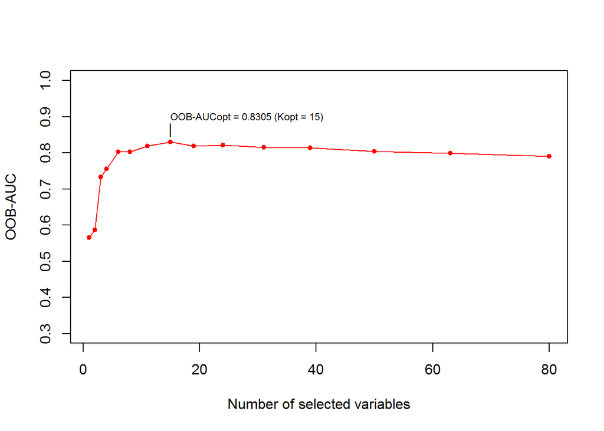

```r
plot(fit_wo_driver_nodesize)
```

Using cross-validation using the model ‘fit_wo_driver_nodesize’:

```r
fit.cv_wo_driver_nodesize = AUCRFcv(fit_wo_driver_nodesize,
                 nCV = 10, ###Number of folds.
                 M = 10) ###Number of CV repetitions.
saveRDS(fit.cv_wo_driver_nodesize,"Models/fit.cv_wo_driver_nodesize.rds")
```

```r
fit.cv_wo_driver_nodesize = readRDS("Models/fit.cv_wo_driver_nodesize.rds")
summary(fit.cv_wo_driver_nodesize) #mean cvAUC  = 0.80
```

```
##
## Number of selected variables: Kopt= 15
## AUC of selected variables: OOB-AUCopt= 0.8304772
## AUC from cross validation: 0.804914
## Importance Measure: MDG
##
##    Selected.Variables Importance Prob.Select
## 1   jerk_quantile.25.   7.029290        1.00
## 2   jerk_quantile.75.   6.582534        1.00
## 3         direct_dist   5.555220        1.00
## 4      attr.turn.v.sd   5.402617        1.00
## 5   attr.turn.ap.mean   5.103659        1.00
## 6     attr.turn.al.sd   4.903491        1.00
## 7     attr.turn.ap.sd   4.799001        1.00
## 8             max.ap.   4.462643        1.00
## 9            accel_sd   3.914674        0.93
## 10 accel_quantile.25.   3.864751        1.00
## 11 accel_quantile.75.   3.721485        0.81
## 12           speed_sd   3.656187        0.85
## 13            jerk_sd   3.445182        0.87
## 14                len   3.422909        0.73
## 15    path_efficiency   3.371679        0.70
```

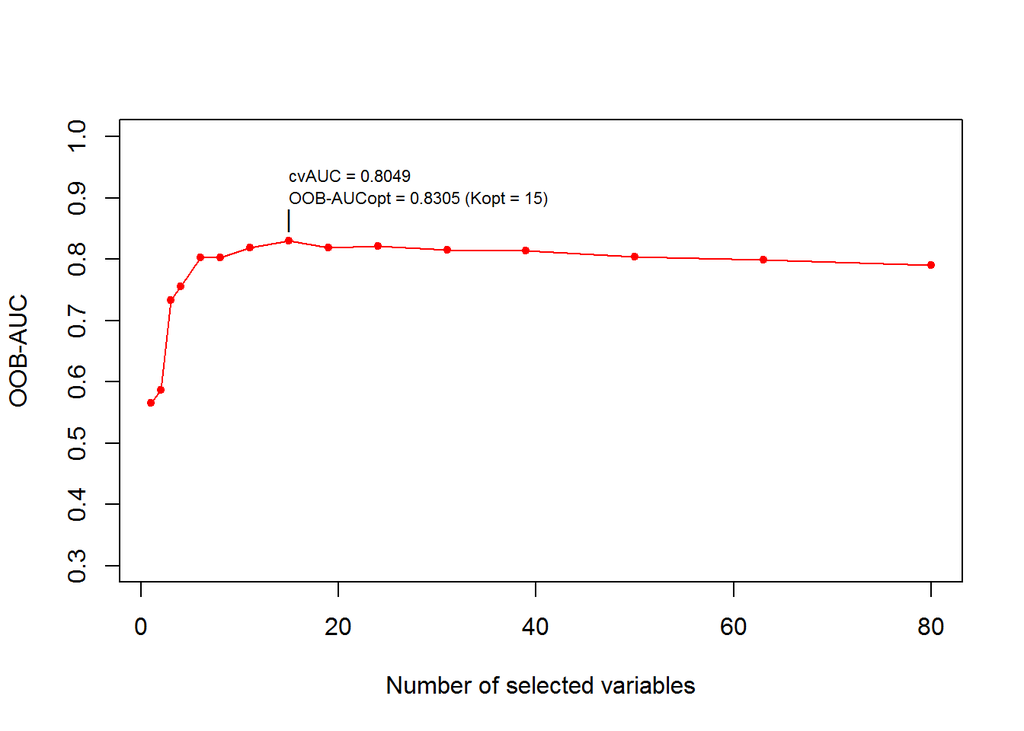

```r
plot(fit.cv_wo_driver_nodesize)
```

```r
names(fit.cv_wo_driver_nodesize)
```

```
##  [1] "call"       "data"       "ranking"    "Xopt"       "OOB-AUCopt"
##  [6] "Kopt"       "AUCcurve"   "RFopt"      "ImpMeasure" "cvAUC"
## [11] "Psel"       "callcv"
```